# Areal Crime Data Kriging

April 23, 2015

In this section, cross-sectional data was aggregated by policing beat and used for space-only Gaussian process (a.k.a Kriging in geospatial aera) prediction. To demonstrate the process, we assume we only know the crime counts of each beat and want to predict crime counts for other places by interpolating over a finer grid.

First of all, we need to add up points over beats and create the connection matrix. In the following analysis, we will be using all available data from year 2008 to year 2014.

```
## with 288 features and 3 fields
## Feature type: wkbPolygon with 2 dimensions
```

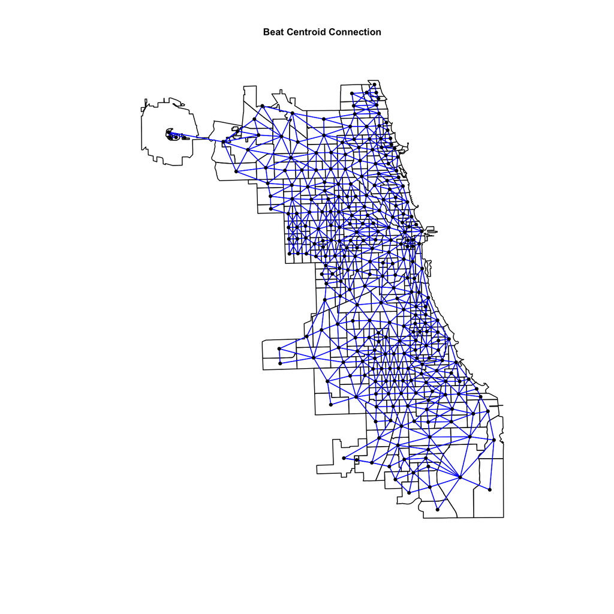

We look at an omnidirectional variogram cloud first. Note that a variogram cloud is a scatter plot of the set of pairs defined as $\{(u_i-u_j, [Z(u_i)-Z(u_j)]^2), \forall i \neq j, i,j=1,2,\ldots,n\}, \text{and } u=u(x,y)$ As we are dealing with count data, we do a log-transform (add a small number $\epsilon=10^{-6}$ for zero values) of the target variable when calculating the sample variogram.

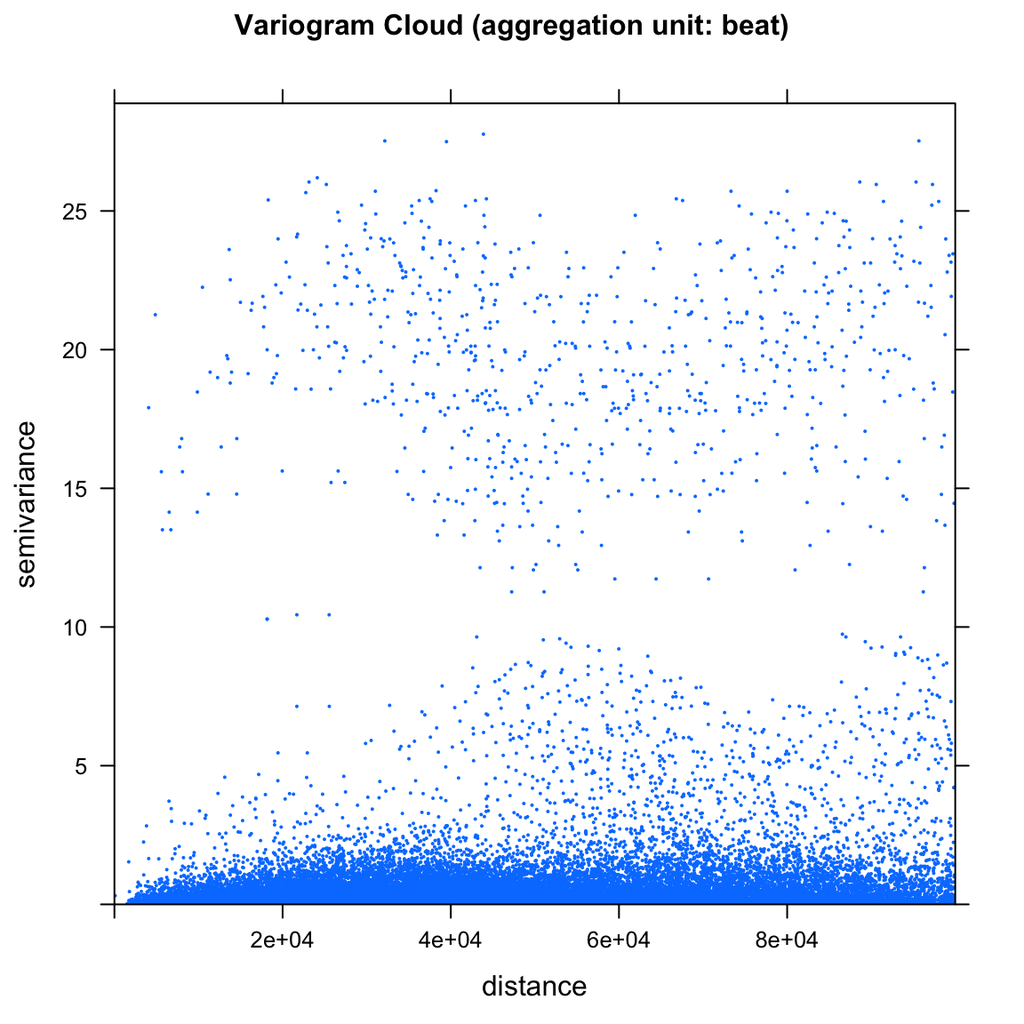

Then We fit the sample variogram by three different models assuming a contant trend. The sample variogram is defined as $\gamma(h)=\frac{1}{2N(h)}\sum_{i=1}^{N(h)}[Z(u_i+h)-Z(u_i)]^2$

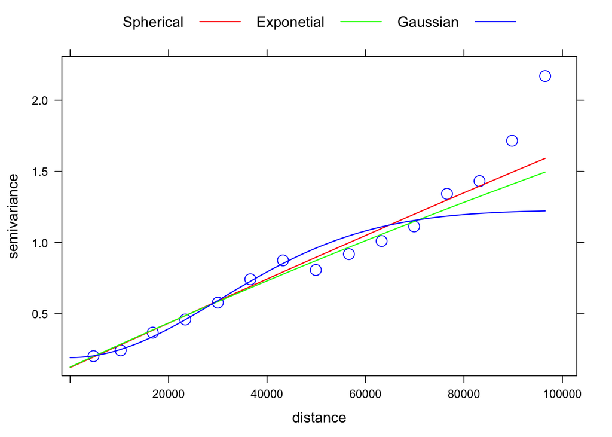

Then assuming a 2D linear trend, we fit the residual sample variogram using the spherical kernel.

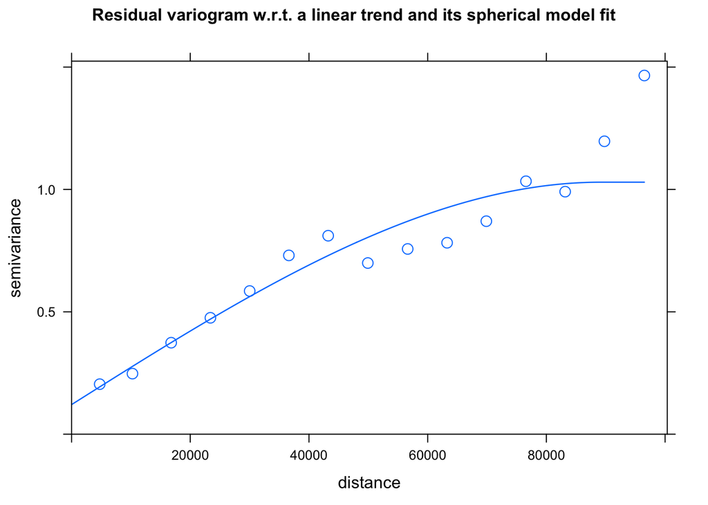

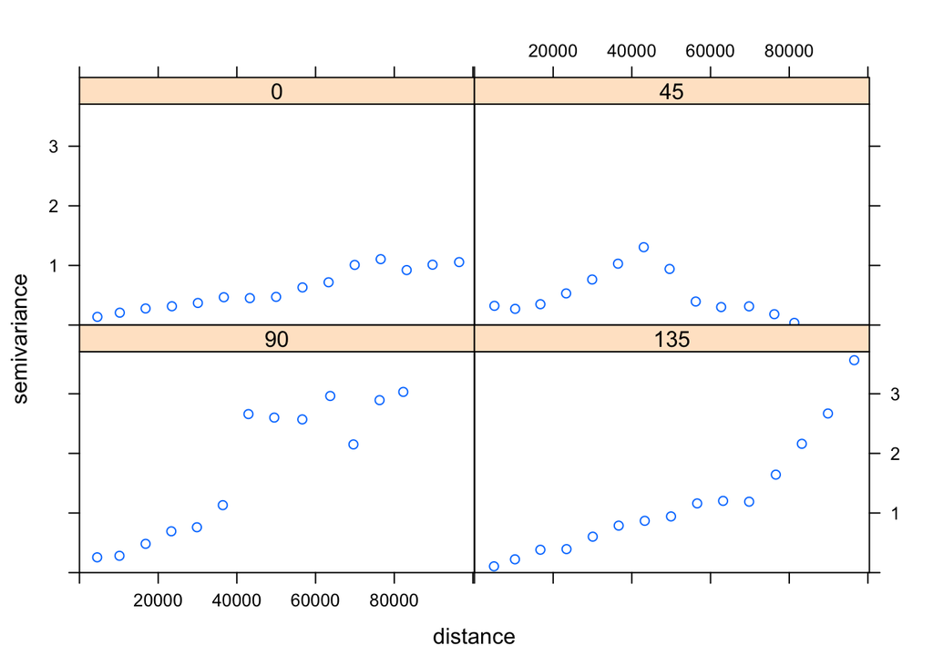

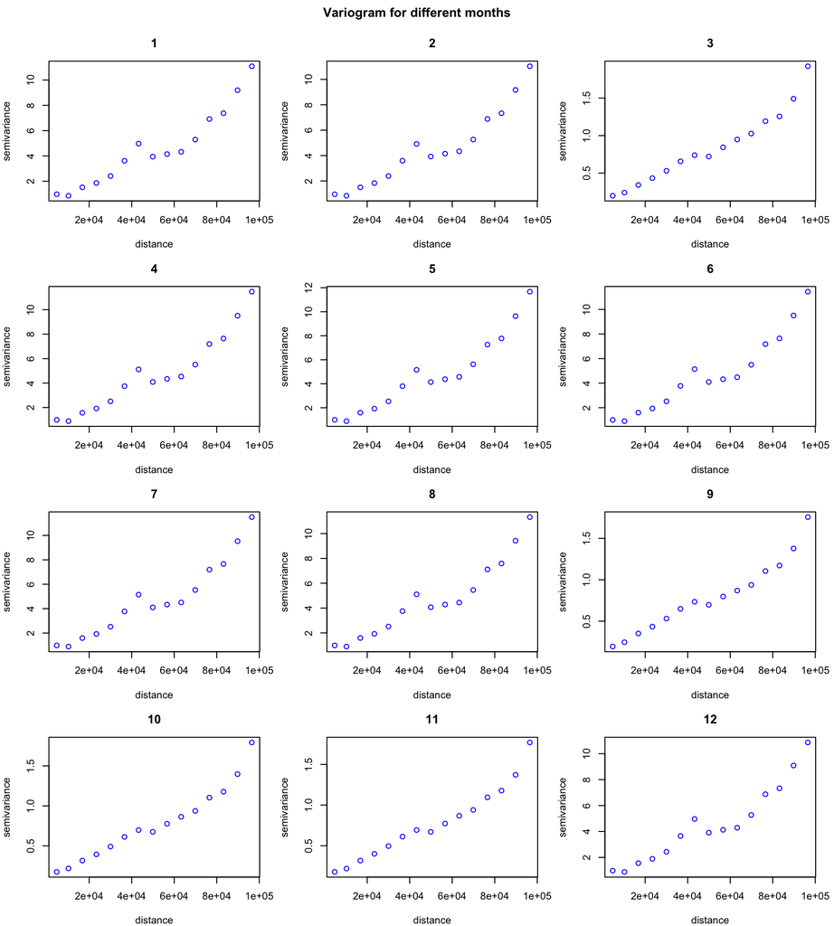

And plot a variogram for each year. There seems to be a downward trend in terms of spatial correlation.

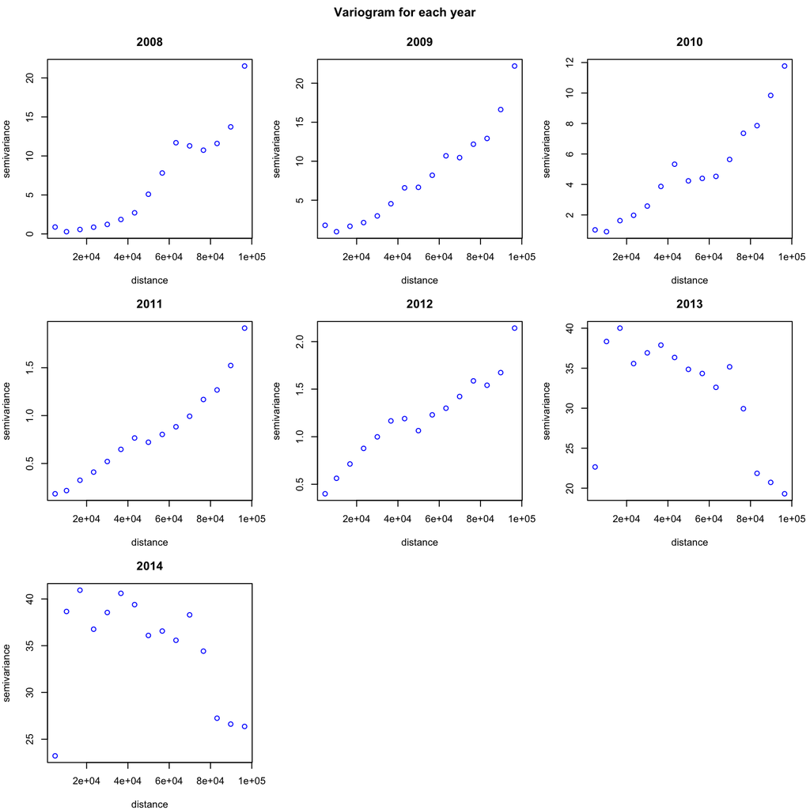

Now let’s move forward to Kriging. We fit the sample variogram by a spherical model. Based on this variogram model, we use Gaussian process to “predict” (interpolate) values on a finer (300 $\times$ 300) grid. To relieve the computational burden, local kriging (here 100 nearest observations was used) was applied instend of using all the observations for a single point kriging prediction.

[figure not shown]

```
## [using ordinary kriging]
```

```
## [1] "Computing Time:"
```

```
##    user  system elapsed
##  33.243   0.067  33.310
```

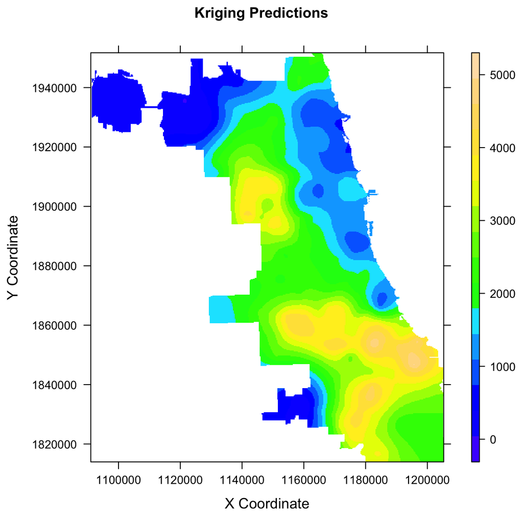

As Gaussian process is a probabilistic framework, we can also show the one standard errors of interpolations for each location. Except for the corners and the boundaries which lack available data, other locations have very close standard errors.

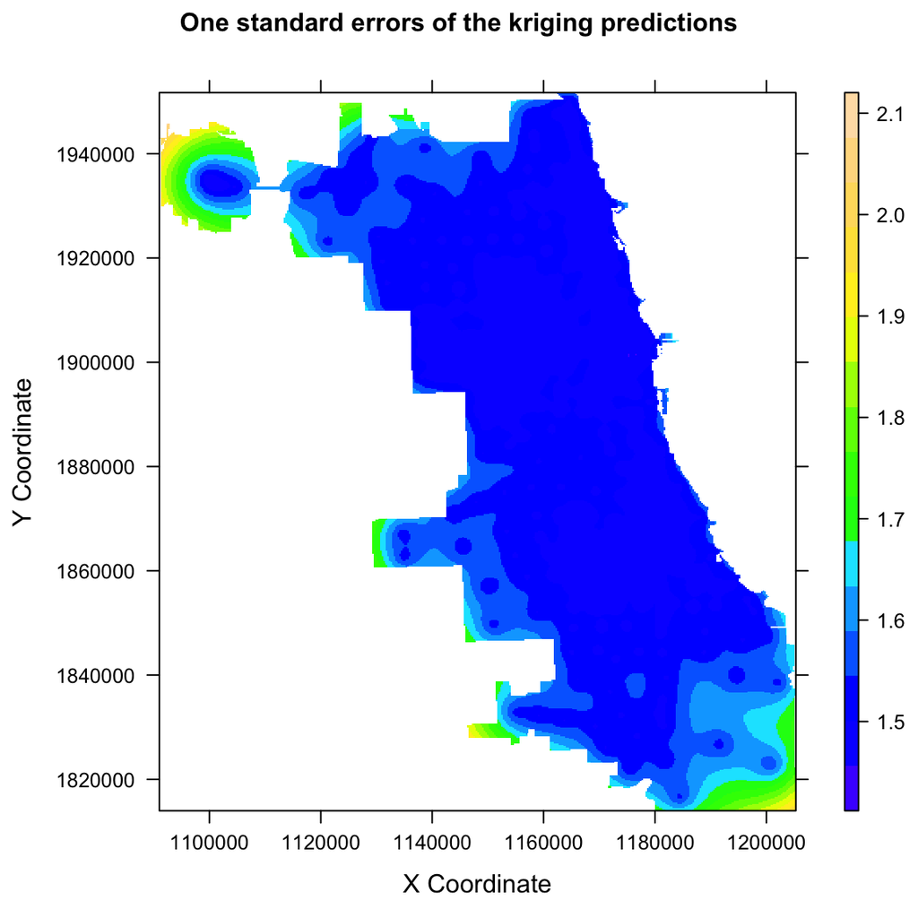